# CPR Study: Statistical Analysis (Run 16)

```r
library(tidyverse)
library(caret)
library(glmnet)
library(dplyr)
library(ROCR)
library(pROC)
library(Metrics)
```

## Data Preprocessing

- Load data
- If any of TSP CDR FCI is assumed, make TKT = 2
- Create Interaction Terms
- Manually assigning categorical variable types
- Set reference variables(levels) for dummy variables
- HMS Binary variable: 1 for 128 and 516, 0 for 515
- Add internations terms (2021/02/15)

```r
data_file = "20210307 Master_TCAD_Final_20210306_assumed less severe acc_use for overall CPR_unique3.csv"
data_combined_subset = read.csv(data_file)

# If any of TSP CDR FCI is assumed, make TKT = 2
data_combined_subset <- data_combined_subset %>%
  mutate(TKT = replace(TKT, (Is.TSP.Assumed==1) + (Is.CDR.Assumed==1) +
                         (Is.FCI.assumed==1) > 0, 2))

# Create Interaction Terms
data_combined_subset <- data_combined_subset %>%
  mutate(TSP_IOF = TSP * IOF) %>%
  mutate(IOF_IOFB = IOF * IOFB) %>%
  mutate(TCL_TCLB = TCL * TCLB) %>%
  mutate(TCLsubFCI = TCL - FCI) %>%
  mutate(TSP_CDR = TSP * CDR) %>%
  mutate(TSPC_CDR = TSPC * CDR) %>%
  mutate(EIS_CDR = EIS.N * CDR)

# Manually assigning categorical variable types
cat_vars = c("TKT", "ACT", "HMS", "SMS", "THT",
              "TFP", "TFN", "JKTHSTBB", "JKTHSTrev",
             "IOFB", "TCLB")
data_combined_subset[, cat_vars] = lapply(data_combined_subset[, cat_vars],
                                          factor)

# Set reference variables(levels) for dummy variables
data_combined_subset <- data_combined_subset %>%
  mutate(ACT = relevel(ACT, ref="1")) %>%
  mutate(THT = relevel(THT, ref="0")) %>%
  mutate(SMS = relevel(SMS, ref="515")) %>%
  mutate(TFP = relevel(TFP, ref="U")) %>%
  mutate(TFN = relevel(TFN, ref="1")) %>%
  mutate(HMS = relevel(HMS, ref="515")) %>%
  mutate(JKTHSTBB = relevel(JKTHSTBB, ref="0")) %>%
  mutate(JKTHSTrev = relevel(JKTHSTrev, ref="0"))

# HMS Binary variable: 1 for 128 and 516, 0 for 515
data_combined_subset <- data_combined_subset %>%
  mutate(HMSB = ifelse(HMS == '515', 0, 1)) %>%
  mutate(SMSB = ifelse(SMS == '515', 0, 1))

# Add internations terms (2021/02/15)
data_combined_subset <- data_combined_subset %>%
  mutate(TSPS = TSP * TSP) %>%
  mutate(EISS = EIS.N * EIS.N) %>%
  mutate(TSPS_CDR = TSPS * CDR) %>%
  mutate(EIS_IOF = EIS.N * IOF) %>%
  mutate(TSPS_IOF = TSPS * IOF) %>%
  mutate(TSPC_IOF = TSPC * IOF) %>%
  mutate(EISS_IOF = EISS * IOF) %>%
  mutate(EISS_CDR = EISS * CDR) %>%
  mutate(TSPC_CDR = TSPC * CDR)
```

- Check for Missing Values in TKT? No missing values.

```r
sum(is.na(data_combined_subset$TKT))
```

[output not shown]

- Form `combined_data` and further split it into training `train_combined` (80%) and test `test_combined` (20%).

```r
var_names <- c("TSP","CDR","JKTHSTBB","TSP_IOF","EIS.N","ACT","HMSB",
               "HID","HMT","Z.indicator","THT","IOF","LDLH","TSPS",
               "EISS","TSP_CDR","TSPS_CDR","EIS_IOF","JKT","STS",
               "SID","EIS_CDR", "LDLS","TSPS_IOF","TSPC","SMSB","TFPB",
               "TSPC_CDR", "LDLT", "LDLB", "NewResponse")
combined_data <- data_combined_subset %>%
  filter(SUBH==1 & SUBS==1 & SUBT==1 & SUBB==1) %>%
   select(all_of(var_names))

set.seed(1231)

train_id <- combined_data$NewResponse %>%
  createDataPartition(p=0.8,list=FALSE)
train_combined <- combined_data[train_id, ]
test_combined <- combined_data[-train_id, ]

#combined_x <- model.matrix(NewResponse~ ., data = train_combined)[,-1]
#combined_y=train_combined$NewResponse
```

## Head

Fit a logistic model with variables selected from LASSO; LASSO variables are selected in prior analysis. Then report various evaluation metrics.

### Logistic summary

```r
head_lasso_vars <- c('TSP', 'CDR', 'JKTHSTBB', 'TSP_IOF', 'EIS.N',
                    'ACT', 'HMSB', 'HID', 'HMT', 'Z.indicator')

head_data_logit <- glm(formula = LDLH ~ .,
                    family = binomial,
                    data = train_combined[, c('LDLH', head_lasso_vars)])
summary(head_data_logit)
```

```
Call:
glm(formula = LDLH ~ ., family = binomial, data = train_combined[,
    c("LDLH", head_lasso_vars)])

Deviance Residuals:
    Min       1Q   Median       3Q      Max
-1.4884  -0.1704  -0.0938  -0.0600   3.6147

Coefficients:
              Estimate Std. Error z value Pr(>|z|)
(Intercept) -0.6795427  2.1077068  -0.322  0.74714
TSP          0.0325975  0.0139049   2.344  0.01906 *
CDR          0.0297909  0.0103693   2.873  0.00407 **
JKTHSTBB1   -0.7159129  0.7671369  -0.933  0.35070
JKTHSTBB2   -1.5600478  0.2023180  -7.711 1.25e-14 ***
JKTHSTBB3   -2.2117594  0.7681332  -2.879  0.00398 **
TSP_IOF     -0.0001091  0.0014016  -0.078  0.93794
EIS.N        0.0048455  0.0119095   0.407  0.68411
ACT2         1.4722635  0.2489308   5.914 3.33e-09 ***
HMSB        -0.8632564  0.2186893  -3.947 7.90e-05 ***
HID         -0.0133736  0.0155455  -0.860  0.38963
HMT         -2.7632597  2.0684451  -1.336  0.18158
Z.indicator -1.3525683  0.2347706  -5.761 8.35e-09 ***
---
Signif. codes:  0 ‘***’ 0.001 ‘**’ 0.01 ‘*’ 0.05 ‘.’ 0.1 ‘ ’ 1

(Dispersion parameter for binomial family taken to be 1)

    Null deviance: 1461.2  on 8075  degrees of freedom
Residual deviance: 1091.5  on 8063  degrees of freedom
AIC: 1117.5

Number of Fisher Scoring iterations: 8
```

### AUC

```r
log_predict <- predict(head_data_logit,
                       newdata = test_combined,
                       type = "response")
auc(test_combined$LDLH, log_predict)
```

```
[1] 0.890448
```

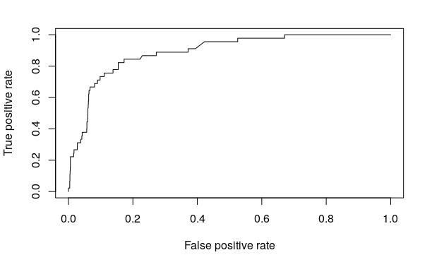

```r
pr=prediction(log_predict, test_combined$LDLH)
perf=performance(pr, measure="tpr", x.measure="fpr")
plot(perf)
```

### Predictive Accuracy

```r
yHat = head_data_logit$fitted.values > 0.5
tab = table(train_combined$LDLH, yHat)
print(tab)
```

```
   yHat
    FALSE TRUE
  0  7926    4
  1   143    3
```

```r
sum(diag(tab))/sum(tab)
```

```
[1] 0.9817979
```

```r
testyHat = log_predict > 0.5
tab = table(test_combined$LDLH, testyHat)
print(tab)
```

```
   testyHat
    FALSE TRUE
  0  1970    4
  1    44    1
```

```r
sum(diag(tab))/sum(tab)
```

```
[1] 0.9762259
```

### Pseudo R^2

McFadden’s Pseudo R^2? (Deviance)

```r
r2Log <- function(model) {
  summaryLog <- summary(model)
  1 - summaryLog$deviance / summaryLog$null.deviance
}
r2Log(head_data_logit)
```

```
[1] 0.2529907
```

## Shell

Fit a logistic model with variables selected from LASSO; LASSO variables are selected in prior analysis. Then report various evaluation metrics.

### Logistic Model

```r
shell_lasso_vars <- c('TSP', 'CDR', 'JKT', 'IOF', 'TSP_IOF', 'EIS.N',
                      'ACT', 'STS', 'SID', 'THT', 'EIS_CDR', 'Z.indicator')
shell_data_logit <- glm(formula = LDLS ~ .,
                        family = binomial,
                        data = train_combined[, c('LDLS', shell_lasso_vars)])
summary(shell_data_logit)
```

```
Call:
glm(formula = LDLS ~ ., family = binomial, data = train_combined[,
    c("LDLS", shell_lasso_vars)])

Deviance Residuals:
    Min       1Q   Median       3Q      Max
-1.4396  -0.1485  -0.0949  -0.0944   3.4933

Coefficients:
              Estimate Std. Error z value Pr(>|z|)
(Intercept) -2.2189355  1.8345907  -1.209 0.226471
TSP         -0.0087129  0.0231491  -0.376 0.706634
CDR          0.0675595  0.0169949   3.975 7.03e-05 ***
JKT         -0.9061764  0.3128817  -2.896 0.003777 **
IOF          0.1861792  0.1075113   1.732 0.083324 .
TSP_IOF     -0.0006251  0.0029179  -0.214 0.830378
EIS.N        0.0823341  0.0180148   4.570 4.87e-06 ***
ACT2        -0.0495634  0.4466710  -0.111 0.911647
STS         -5.8190302  1.9917836  -2.922 0.003483 **
SID         -0.0040154  0.0137326  -0.292 0.769981
THT1        -0.1991927  0.3216049  -0.619 0.535672
EIS_CDR     -0.0010644  0.0004160  -2.558 0.010514 *
Z.indicator -0.9120244  0.2552347  -3.573 0.000353 ***
---
Signif. codes:  0 ‘***’ 0.001 ‘**’ 0.01 ‘*’ 0.05 ‘.’ 0.1 ‘ ’ 1

(Dispersion parameter for binomial family taken to be 1)

    Null deviance: 1587.3  on 8075  degrees of freedom
Residual deviance: 1126.0  on 8063  degrees of freedom
AIC: 1152

Number of Fisher Scoring iterations: 8
```

### AUC

```r
log_predict <- predict(shell_data_logit,
                       newdata = test_combined,
                       type = "response")
auc(test_combined$LDLS, log_predict)
```

```
[1] 0.9166787
```

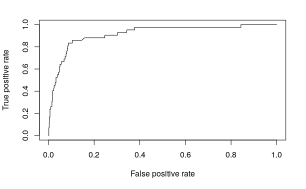

```r
pr <- prediction(log_predict, test_combined$LDLS)
perf <- performance(pr, measure="tpr", x.measure="fpr")
plot(perf)
```

### Predictive Accuracy

```r
yHat = shell_data_logit$fitted.values > 0.5
tab = table(train_combined$LDLS, yHat)
print(tab)
```

```
   yHat
    FALSE TRUE
  0  7903   11
  1   148   14
```

```r
sum(diag(tab))/sum(tab)
```

```
[1] 0.980312
```

```r
testyHat = log_predict > 0.5
tab = table(test_combined$LDLS, testyHat)
print(tab)
```

```
   testyHat
    FALSE TRUE
  0  1973    4
  1    39    3
```

```r
sum(diag(tab))/sum(tab)
```

```
[1] 0.9787023
```

### Pseudo R^2

McFadden’s Pseudo R^2? (Deviance)

```r
r2Log(shell_data_logit)
```

```
[1] 0.290617
```

## Top

Fit a logistic model with variables selected from LASSO; LASSO variables are selected in prior analysis. Then report various evaluation metrics.

### Logistic Model

```r
top_lasso_vars <- c('TSP', 'TSPC', 'CDR', 'JKT', 'IOF', 'TSP_IOF', 'EIS.N',
                    'ACT', 'SMSB', 'STS', 'TFPB', 'TSP_CDR', 'TSPC_CDR',
                    'EIS_CDR', 'Z.indicator')
top_data_logit <- glm(formula = LDLT ~ .,
                      family = binomial,
                      data = train_combined[, c('LDLT', top_lasso_vars)])
summary(top_data_logit)
```

```
Call:
glm(formula = LDLT ~ ., family = binomial, data = train_combined[,
    c("LDLT", top_lasso_vars)])

Deviance Residuals:
    Min       1Q   Median       3Q      Max
-1.6926  -0.2664  -0.1303  -0.0952   3.5644

Coefficients:
              Estimate Std. Error z value Pr(>|z|)
(Intercept) -3.8600384  1.0526368  -3.667 0.000245 ***
TSP         -0.0657693  0.0345601  -1.903 0.057035 .
TSPC         1.1806976  0.5862289   2.014 0.044004 *
CDR          0.1892179  0.0856372   2.210 0.027138 *
JKT         -1.4133546  0.1218927 -11.595  < 2e-16 ***
IOF         -0.1498312  0.0806894  -1.857 0.063327 .
TSP_IOF      0.0032637  0.0023297   1.401 0.161244
EIS.N        0.0230410  0.0184404   1.249 0.211488
ACT2        -0.2813920  0.2279342  -1.235 0.217005
SMSB        -0.6291469  0.1359300  -4.628 3.68e-06 ***
STS          1.9280053  1.0742434   1.795 0.072693 .
TFPB        -0.6792415  0.2114716  -3.212 0.001318 **
TSP_CDR      0.0018116  0.0013081   1.385 0.166098
TSPC_CDR    -0.0703598  0.0386949  -1.818 0.069015 .
EIS_CDR      0.0001855  0.0005501   0.337 0.735971
Z.indicator -2.5549915  0.1880491 -13.587  < 2e-16 ***
---
Signif. codes:  0 ‘***’ 0.001 ‘**’ 0.01 ‘*’ 0.05 ‘.’ 0.1 ‘ ’ 1

(Dispersion parameter for binomial family taken to be 1)

    Null deviance: 2875.5  on 8075  degrees of freedom
Residual deviance: 2189.4  on 8060  degrees of freedom
AIC: 2221.4

Number of Fisher Scoring iterations: 7
```

### AUC

```r
log_predict <- predict(top_data_logit,
                       newdata = test_combined,
                       type = "response")
auc(test_combined$LDLT, log_predict)
```

```
[1] 0.8511619
```

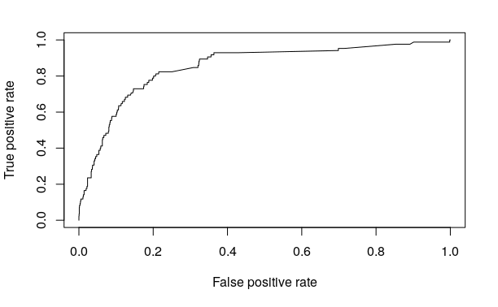

```r
pr <- prediction(log_predict, test_combined$LDLT)
perf <- performance(pr, measure="tpr", x.measure="fpr")
plot(perf)
```

### Predictive Accuracy

```r
yHat = top_data_logit$fitted.values > 0.5
tab = table(train_combined$LDLT, yHat)
print(tab)
```

```
   yHat
    FALSE TRUE
  0  7713   14
  1   329   20
```

```r
sum(diag(tab))/sum(tab)
```

```
[1] 0.9575285
```

```r
testyHat = log_predict > 0.5
tab = table(test_combined$LDLT, testyHat)
print(tab)
```

```
   testyHat
    FALSE TRUE
  0  1927    7
  1    77    8
```

```r
sum(diag(tab))/sum(tab)
```

```
[1] 0.9583952
```

### Pseudo R^2

McFadden’s Pseudo R^2? (Deviance)

```r
r2Log(top_data_logit)
```

[output not shown]

## Bottom

Fit a logistic model with variables selected from LASSO; LASSO variables are selected in prior analysis. Then report various evaluation metrics.

### Logistic Model

```r
bottom_lasso_vars <- c('CDR', 'JKT', 'TSP_IOF', 'EIS.N', 'ACT', 'STS',
                       'EIS_CDR', 'Z.indicator')
bottom_data_logit <- glm(formula = LDLB ~ .,
                         family = binomial,
                         data = train_combined[, c('LDLB', bottom_lasso_vars)])
summary(bottom_data_logit)
```

```
Call:
glm(formula = LDLB ~ ., family = binomial, data = train_combined[,
    c("LDLB", bottom_lasso_vars)])

Deviance Residuals:
    Min       1Q   Median       3Q      Max
-1.2274  -0.1701  -0.0887  -0.0887   3.6171

Coefficients:
              Estimate Std. Error z value Pr(>|z|)
(Intercept) -0.1000294  1.1053175  -0.090 0.927891
CDR          0.0519233  0.0156135   3.326 0.000882 ***
JKT         -1.4082077  0.1829826  -7.696 1.41e-14 ***
TSP_IOF     -0.0003030  0.0010836  -0.280 0.779793
EIS.N        0.0679080  0.0108807   6.241 4.34e-10 ***
ACT2        -0.8501502  0.5245792  -1.621 0.105096
STS         -8.0882611  2.4178784  -3.345 0.000822 ***
EIS_CDR     -0.0011613  0.0003299  -3.520 0.000432 ***
Z.indicator -1.6085314  0.2372838  -6.779 1.21e-11 ***
---
Signif. codes:  0 ‘***’ 0.001 ‘**’ 0.01 ‘*’ 0.05 ‘.’ 0.1 ‘ ’ 1

(Dispersion parameter for binomial family taken to be 1)

    Null deviance: 1453.2  on 8075  degrees of freedom
Residual deviance: 1116.8  on 8067  degrees of freedom
AIC: 1134.8

Number of Fisher Scoring iterations: 8
```

### AUC

```r
log_predict <- predict(bottom_data_logit,
                       newdata = test_combined,
                       type = "response")
auc(test_combined$LDLB, log_predict)
```

```
[1] 0.9087565
```

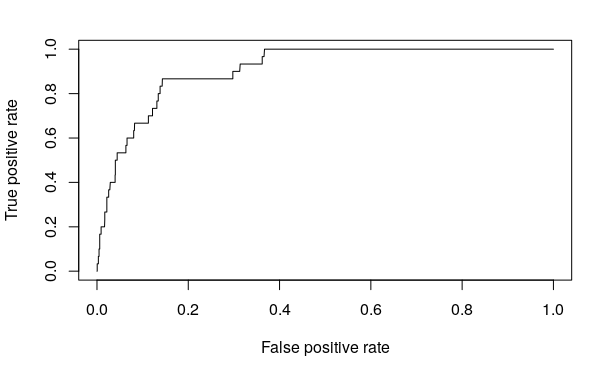

```r
pr <- prediction(log_predict, test_combined$LDLB)
perf <- performance(pr, measure="tpr", x.measure="fpr")
plot(perf)
```

### Predictive Accuracy

```r
yHat = bottom_data_logit$fitted.values > 0.5
tab = table(train_combined$LDLB, yHat)
print(tab)
```

```
   yHat
    FALSE TRUE
  0  7930    1
  1   145    0
```

```r
sum(diag(tab))/sum(tab)
```

```
[1] 0.9819217
```

```r
testyHat = log_predict > 0.5
tab = table(test_combined$LDLB, testyHat)
print(tab)
```

```
   testyHat
    FALSE
  0  1989
  1    30
```

```r
sum(diag(tab))/sum(tab)
```

```
[1] 0.9851412
```

### Pseudo R^2

McFadden’s Pseudo R^2? (Deviance)

```r
r2Log(bottom_data_logit)
```

```
[1] 0.2314405
```

## Overal CPR

```r
# Fit head/shell/top/bottom logistic models
head_data_logit <- glm(formula = LDLH ~ .,
                    family = binomial,
                    data = combined_data[, c('LDLH', head_lasso_vars)])
shell_data_logit <- glm(formula = LDLS ~ .,
                        family = binomial,
                        data = combined_data[, c('LDLS', shell_lasso_vars)])
top_data_logit <- glm(formula = LDLT ~ .,
                      family = binomial,
                      data = combined_data[, c('LDLT', top_lasso_vars)])
bottom_data_logit <- glm(formula = LDLB ~ .,
                         family = binomial,
                         data = combined_data[, c('LDLB', bottom_lasso_vars)])


# Create a new dataframe `combined_data2`
combined_data2 = data.frame(NewResponse = combined_data$NewResponse)
combined_data2$cpr_head = head_data_logit$fitted.values
combined_data2$cpr_shell = shell_data_logit$fitted.values
combined_data2$cpr_top = top_data_logit$fitted.values
combined_data2$cpr_bottom = bottom_data_logit$fitted.values


#  All interaction model
run16_logit = glm(formula = NewResponse ~ cpr_head*cpr_shell*cpr_top*cpr_bottom,
                  family = binomial, data = combined_data2)

# Pairwise interaction model
run16_logit_pair = glm(NewResponse ~.^2,
                             family = binomial, data = combined_data2)

# Triple interaction model
run16_logit_triple = glm(NewResponse ~.^3,
                             family = binomial, data = combined_data2)

# Form prediction
newcars = data.frame(
  cpr_head = c(0.09118543, 0.04822973, 0.01818723, 0.01135243, 0.008959692),
  cpr_shell= c(0.1483996, 0.06365662, 0.06365662, 0.02931969, 0.0197362),
  cpr_top = c(0.348481, 0.1412546, 0.1412546, 0.07015777, 0.0668602),
  cpr_bottom = c(0.1291767, 0.04821325, 0.04821325, 0.01286633, 0)
)
rownames(newcars) = paste("run16_car", 1:5, sep='')
newcars$cum_cpr_all = predict(run16_logit, newcars,
                              type = "response")
newcars$cum_cpr_pairwise = predict(run16_logit_pair, newcars,
                                   type = "response")
newcars$cum_cpr_triple = predict(run16_logit_triple, newcars,
                                 type = "response")
```

Create a new data frame `combined_data2` with five columns: `NewResponse` and the four predictions (probabilities) from the head, shell, top, and bottom logistic models.

Then, fit three logistic models based on

- **All-Interactions** among the four predictions;
- **Pairse-Interactions** among the four predictions;
- **Triple-Interactions** among the four predictions.

The prediction for five newcars are summarized as follows.

```r
as.matrix(round(newcars, dig=4))
```

```
           cpr_head cpr_shell cpr_top cpr_bottom cum_cpr_all cum_cpr_pairwise
run16_car1   0.0912    0.1484  0.3485     0.1292      0.5298           0.7322
run16_car2   0.0482    0.0637  0.1413     0.0482      0.2978           0.2237
run16_car3   0.0182    0.0637  0.1413     0.0482      0.2726           0.2052
run16_car4   0.0114    0.0293  0.0702     0.0129      0.0886           0.0737
run16_car5   0.0090    0.0197  0.0669     0.0000      0.0631           0.0623
           cum_cpr_triple
run16_car1         0.5973
run16_car2         0.2765
run16_car3         0.2459
run16_car4         0.0796
run16_car5         0.0609
```